Grupo de estadística para el estudio del lenguaje

Federico Alvarez - **FFyL-UBA**

Charo Zacchigna - **FFyL-UBA**

## Conformación

- Estudiantes e investigadores de diferentes áreas de la lingüística
- Necesidad de incorporar herramientas teórico-prácticas
- Área de vacancia en la carrera de Letras

## Integrantes

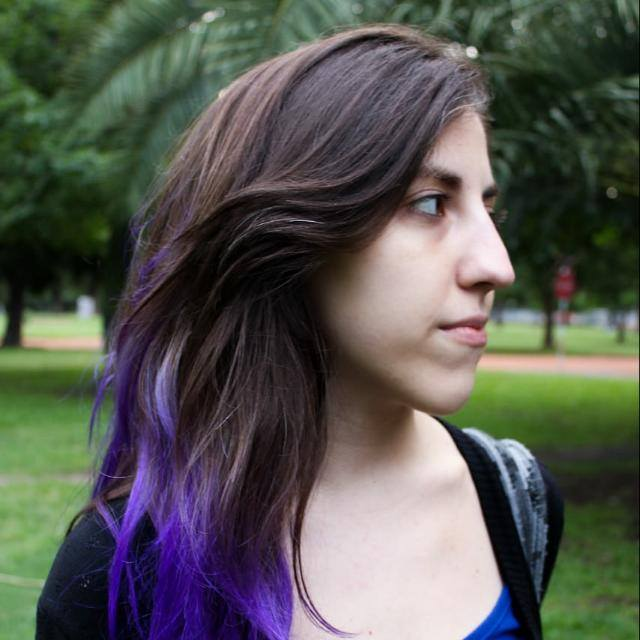

**Charo Zacchigna** **Mercedes Güemes**

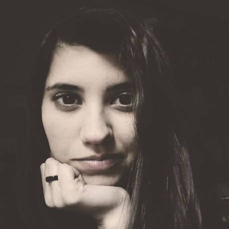

**Laura Tallon**

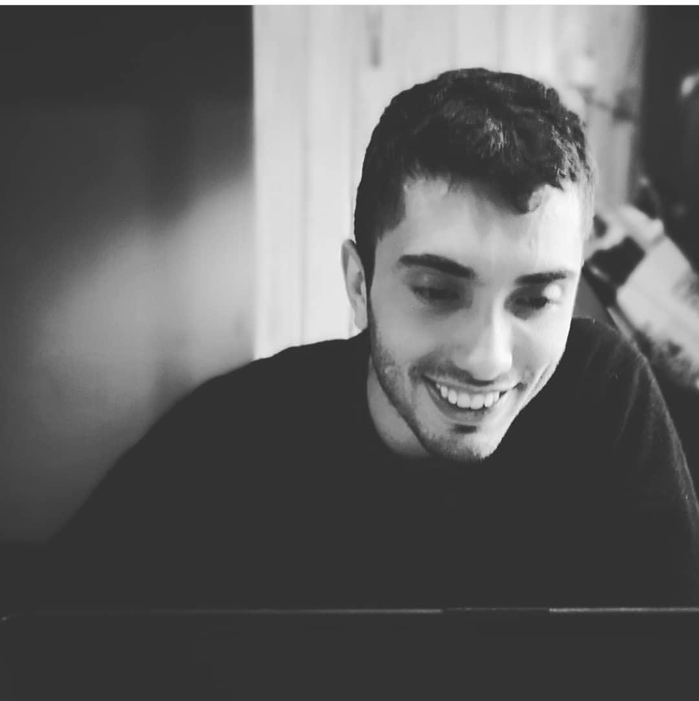

**Santiago Gualchi**

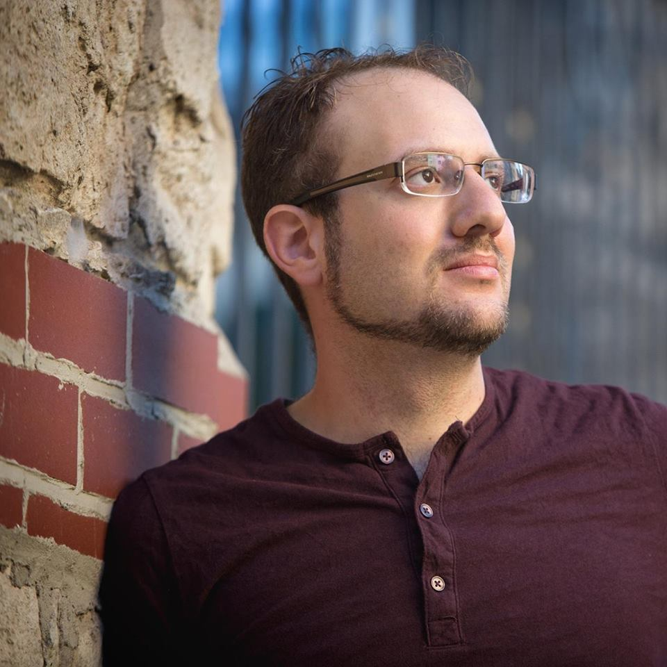

**Ezequiel Koile**

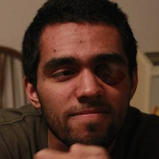

**Federico Alvarez**

## Historia

- Seminario Caro Gattei
- Grupo de Lingüística Computacional
- Iniciativa en grupo Lingüística Argentina; reunión con Eze Koile

## Herramientas teórico-prácticas

¿Por qué son necesarias?

- Dificultad para interpretar críticamente la metodología empleada en trabajos de investigación
- Falta de formación en aspectos formales de recolección de datos
- Incapacidad del investigador para analizar los datos que recolecta; necesidad de recurrir a personas con formación cuantitativa pero sin formación en el campo
- Dificultad en el acceso al circuito de publicación

## Problemas en el acceso a la disciplina

- Hay muy pocos recursos para aprender estadística desde una perspectiva orientada al estudio del lenguaje. Ninguno en español

## Algunas ventajas de los métodos cuantitativos

- Mayor rigor metodológico: falsabilidad, replicabilidad
- Lenguaje común con otras disciplinas científicas
- Aplicable en cualquier área del conocimiento lingüístico

## Objetivos

- Relevamiento metodológico del campo
- Generación de material de estudio en español orientado a la lingüística
- Difundir y promover el empleo de metodología cuantitativa
- Investigar las posibilidades de implementación de modelos estadísticos en el análisis de datos lingüísticos y en la construcción de teorías sobre el lenguaje

## Actividades

- Planificación del temario. Formación en fundamentos teóricos de la estadística y la probabilidad
- Elementos básicos de programación en R para el análisis y la visualización de datos
- Reuniones quincenales con exposiciones rotativas
- Generación y compilación de material de estudio. Difusión

Github:

**gesel.github.io**

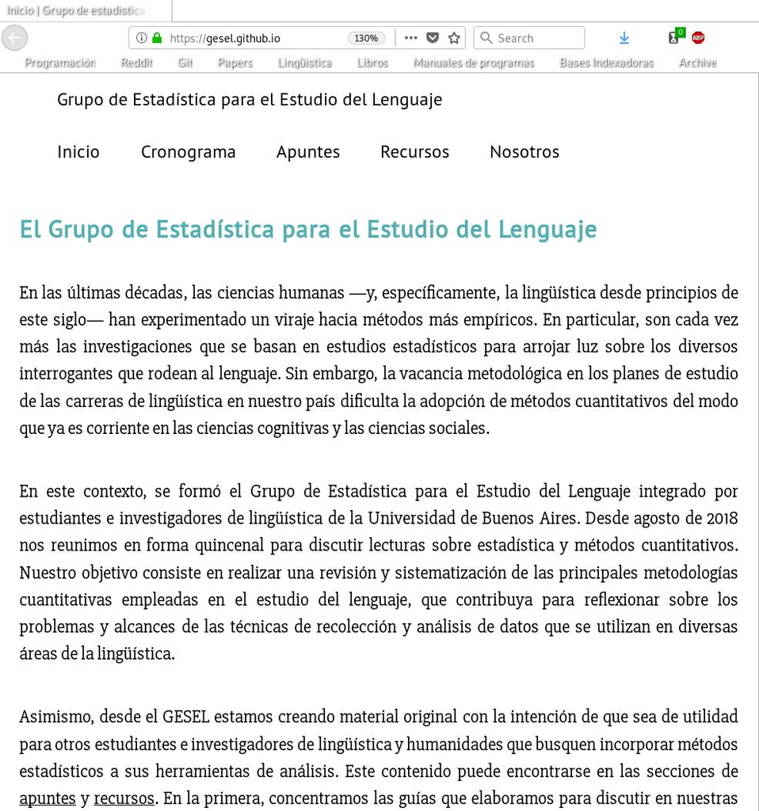

Facebook:

**Grupo de estadística para el estudio del lenguaje**

[figure not shown]

## Perspectivas

- Institucionalización del grupo
- Participación en eventos académicos
- Profundización del temario; implementación en R
- Recopilación del material generado